# Week 10 Recitation - Multiple comparisons

Natalie Kerr, Eric R. Scott

This week will be introducing the functions for multiple comparisons in R. We will introduce both Tukey’s HSD and Bonferroni tests for ANOVA, as well as the Dunn’s test for the Kruskal-Wallis test.

```r
# Old packages
library(ggplot2) # for ggplot()
library(ggformula) # stat_qqline() for creating the normality line in the QQ plot
library(dplyr) # for data wrangling
library(car) # leveneTest()
# New packages, so remember to install!
library(multcomp) # glht() for Bonferroni test
library(dunn.test) # dunn.test()
```

### Lecture 1. Circadian shift data

Here, we will be using the circadian shift data to learn multiple comparisons. This dataset compares phase shift in the circadian rhythm of melatonin production in participants given alternative light treatments (light exposed to eyes, knees, or the control). We want to know whether light treatment alters the circadian rhythm of melatonin production.

```r
cir <- read.csv("CircadianShift.csv")
head(cir) # retrieves the first 6 rows of our data. This is preferred, than all your data.
```

|  | treatment | shift |
| --- | --- | --- |
| 1 | control | 0.53 |
| 2 | control | 0.36 |
| 3 | control | 0.20 |
| 4 | control | -0.37 |
| 5 | control | -0.60 |
| 6 | control | -0.64 |

```r
cir[1:10, ] # cir[rows, columns], so therefore I want to look at rows 1 to 10, and all columns (none specified means all)
```

|  | treatment | shift |
| --- | --- | --- |
| 1 | control | 0.53 |
| 2 | control | 0.36 |
| 3 | control | 0.20 |
| 4 | control | -0.37 |
| 5 | control | -0.60 |
| 6 | control | -0.64 |
| 7 | control | -0.68 |
| 8 | control | -1.27 |
| 9 | knee | 0.73 |
| 10 | knee | 0.31 |

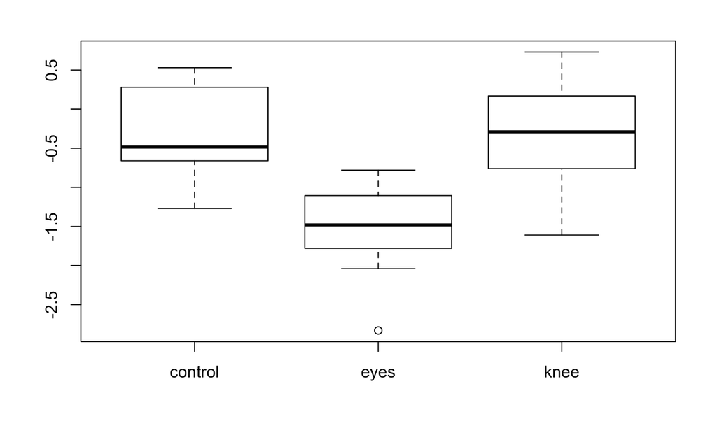

```r
boxplot(shift ~ treatment, data=cir) # let's look at the data
```

### Lecture 2. Select appropriate model

```r
## We have three treatments. What test can we use?
cir.aov <- aov(shift ~ treatment, data = cir)
## Tests for the assumptions
# 1. Formal checks
shapiro.test(cir.aov$residuals) # normal data
```

```
    Shapiro-Wilk normality test

data:  cir.aov$residuals
W = 0.95893, p-value = 0.468
```

```r
leveneTest(shift ~ treatment, data=cir) # equal variances
```

```
Levene's Test for Homogeneity of Variance (center = median)
      Df F value Pr(>F)
group  2  0.1586 0.8545
      19
```

```r
# 2. Visual checks
cir %>% group_by(treatment) %>% summarise(mean = mean(shift),
                                          median = median(shift),
                                          var = var(shift))
```

| treatment | mean | median | var |
| --- | --- | --- | --- |
| control | -0.3087500 | -0.485 | 0.3813839 |
| eyes | -1.5514286 | -1.480 | 0.4988810 |
| knee | -0.3357143 | -0.290 | 0.6253952 |

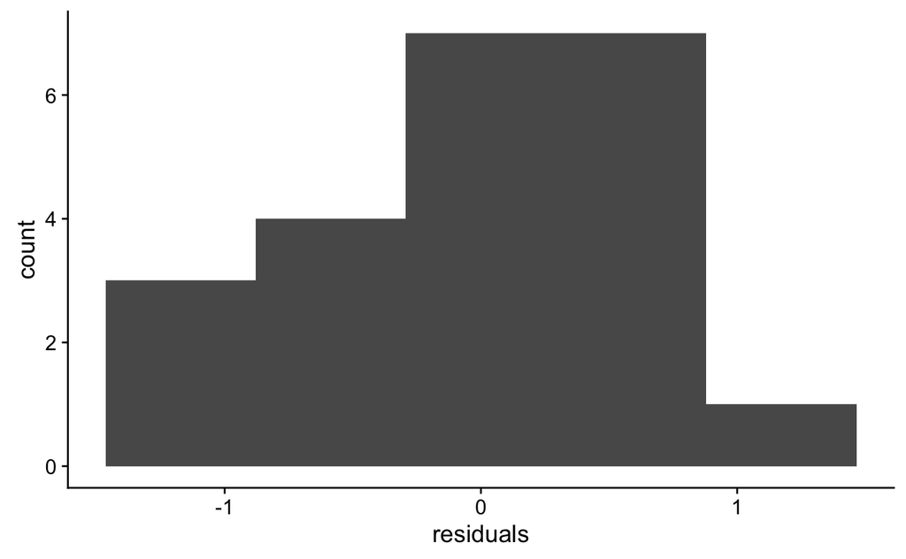

```r
shift.res <- data.frame(residuals = cir.aov$residuals)
ggplot(shift.res, aes(x = residuals)) + # histogram of residuals
  geom_histogram(bins = 5)
```

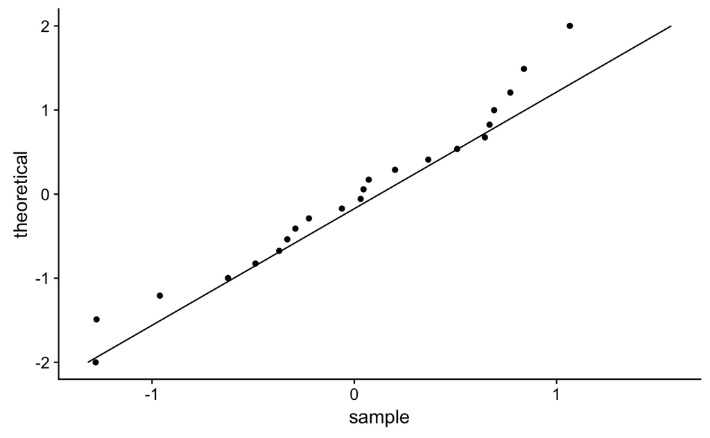

```r
ggplot(shift.res, aes(sample = residuals)) +
  geom_qq() +
  stat_qqline() + # gives you the line to match against residuals to check for nomrality
  coord_flip() # swap axes (to match what Sara and the textbook provides you)
```

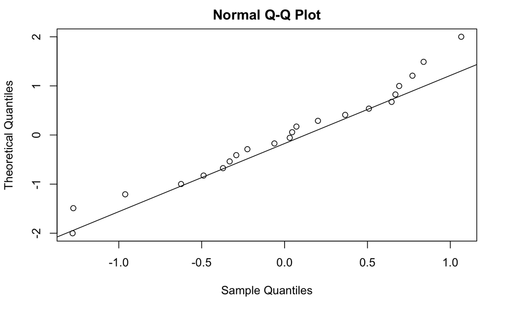

```r
qqnorm(cir.aov$residuals, datax = TRUE); qqline(cir.aov$residuals, datax = TRUE) # non-ggplot way
```

```r
## Do groups differ?
Anova(cir.aov) # gives you ANOVA table with F value, df and p-value (from car package)
```

```
Anova Table (Type II tests)

Response: shift
          Sum Sq Df F value   Pr(>F)
treatment 7.2245  2  7.2894 0.004472 **
Residuals 9.4153 19
---
Signif. codes:  0 ‘***’ 0.001 ‘**’ 0.01 ‘*’ 0.05 ‘.’ 0.1 ‘ ’ 1
```

```r
anova(cir.aov) # (from base R)
```

```
Analysis of Variance Table

Response: shift
          Df Sum Sq Mean Sq F value   Pr(>F)
treatment  2 7.2245  3.6122  7.2894 0.004472 **
Residuals 19 9.4153  0.4955
---
Signif. codes:  0 ‘***’ 0.001 ‘**’ 0.01 ‘*’ 0.05 ‘.’ 0.1 ‘ ’ 1
```

```r
#For this problem, Anova() and anova() give identical results, but for more complicated ANOVA models use Anova from the car package--it usually is more likely to give you the correct p-values.
```

### Lecture 3. Multiple comparisons

#### 3a. Tukey’s test

Running all possible pairwise comparisons to delineate which groups are statistically different.

```r
TukeyHSD(cir.aov) # p adjusted tells you whether the two groups differ
```

```
  Tukey multiple comparisons of means
    95% family-wise confidence level

Fit: aov(formula = shift ~ treatment, data = cir)

$treatment
                    diff        lwr        upr     p adj
eyes-control -1.24267857 -2.1682364 -0.3171207 0.0078656
knee-control -0.02696429 -0.9525222  0.8985936 0.9969851
knee-eyes     1.21571429  0.2598022  2.1716263 0.0116776
```

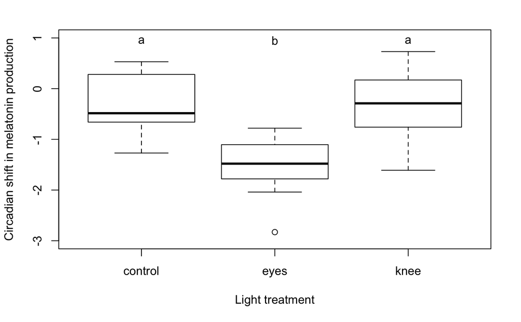

```r
boxplot(shift ~ treatment,
        data = cir,
        ylim = c(-3, 1),
        xlab = "Light treatment",
        ylab = "Circadian shift in melatonin production")
# Manually work out levels
letters <- c("a", "b", "a")
text(x = 1:3, y = 0.95, labels = letters)
```

** Reordering treatment in boxplot to make this more visually pleasing **

```r
levels(cir$treatment) # this is the order
```

```
[1] "control" "eyes"    "knee"
```

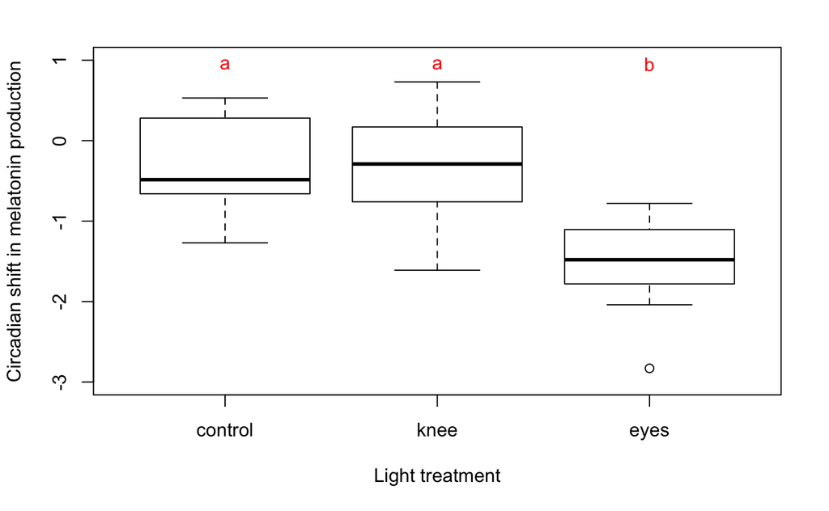

```r
cir$treatment <- factor(cir$treatment, levels=c("control", "knee", "eyes")) # we can reorder them. HOWEVER - what if you misspell a word or use upper case "Control"? Spoiler: it replaces the factor with N/A values, so remember to spell and use upper/lower exactly the way the factors are used in the original data frame
letters <- c("a", "a", "b")
boxplot(shift ~ treatment,
        data = cir,
        ylim = c(-3, 1),
        xlab = "Light treatment",
        ylab = "Circadian shift in melatonin production")
text(x = 1:3, y = 0.95, labels = letters, col="red")
```

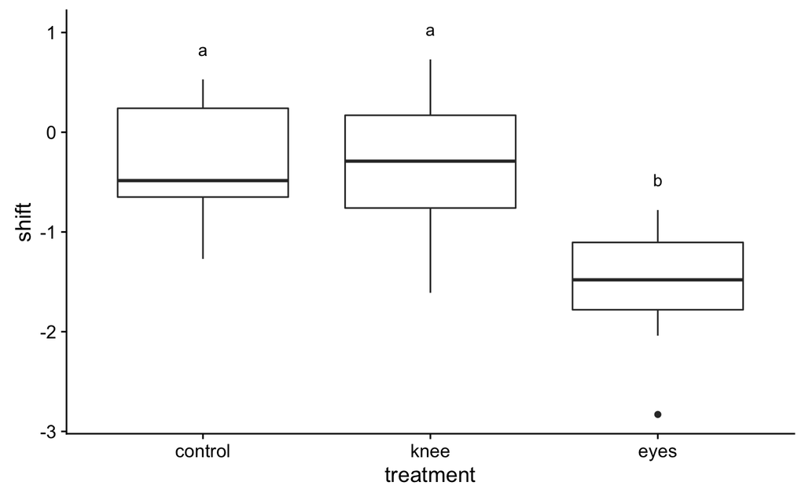

```r
## ggplot way:
ggplot(cir, aes(x = treatment, y = shift)) + #set up data and aesthetics
  geom_boxplot() + #add boxplot layer
  stat_summary(fun.y = "max", #what function to use to come up with the y values.  Try changing to "mean"
               geom = "text", #what kind of geom_ do we want to use? "label" is another alternative
               label = letters, #arguments passed to geom_text()
               position = position_nudge(y = 0.3))
```

```r
  #stat_summary must be used instead of geom_text() because the latter acts on every single data point, not on the 3 points that we want.
```

#### 3b. Bonferroni test

This method allows for selecting a limited set of pairwise comparisons (the comparisons of interest) to reduce type 1 error.

```r
shift.bonf <- glht(cir.aov,
                   linfct = mcp(treatment = c("eyes - control = 0", # mcp is writing out your comparisons under your group name
                                              "knee - control = 0"))) # linear hypotheses (linfct) where your null hypotheses is eyes - control is 0
summary(shift.bonf, test = adjusted("bonferroni")) # bonferroni can change either the alpha or p-value. In lecture, we adjusted the probability of type 1 (alpha) error by dividing it by X number of comparisons. This test adjusts the p-value instead by multiplying it by X number of comaprisons. Both end up with the same result.
```

```
     Simultaneous Tests for General Linear Hypotheses

Multiple Comparisons of Means: User-defined Contrasts


Fit: aov(formula = shift ~ treatment, data = cir)

Linear Hypotheses:
                    Estimate Std. Error t value Pr(>|t|)
eyes - control == 0 -1.24268    0.36433  -3.411  0.00586 **
knee - control == 0 -0.02696    0.36433  -0.074  1.00000
---
Signif. codes:  0 ‘***’ 0.001 ‘**’ 0.01 ‘*’ 0.05 ‘.’ 0.1 ‘ ’ 1
(Adjusted p values reported -- bonferroni method)
```

```r
summary(shift.bonf, test = adjusted("none")) # p-values are not adjusted, therefore times 2 of the bonferroni adjusted values.
```

```
     Simultaneous Tests for General Linear Hypotheses

Multiple Comparisons of Means: User-defined Contrasts


Fit: aov(formula = shift ~ treatment, data = cir)

Linear Hypotheses:
                    Estimate Std. Error t value Pr(>|t|)
eyes - control == 0 -1.24268    0.36433  -3.411  0.00293 **
knee - control == 0 -0.02696    0.36433  -0.074  0.94178
---
Signif. codes:  0 ‘***’ 0.001 ‘**’ 0.01 ‘*’ 0.05 ‘.’ 0.1 ‘ ’ 1
(Adjusted p values reported -- none method)
```

### Exercise 1. Practicing multiple comparisons

*Data*: The counts of insects in agricultural experimental units treated with different insecticides (sprays = A, B and C). Let’s say that C spray was an organic insectide (like tobacco spray) and the other two are synthetic chemicals.

*Instructions:* 1. Run an ANOVA (assume that all assumptions have been met). 2. Conduct a multiple comparison that you think is relevant. 3. Plot your results. 4. Write a summary statement for both the ANOVA and multiple comparison tests.

```r
insect <- read.csv("InsectSpray.csv")
head(insect)
```

|  | X | count | spray |
| --- | --- | --- | --- |
| 1 | 1 | 10 | A |
| 2 | 2 | 7 | A |
| 3 | 3 | 20 | A |
| 4 | 4 | 14 | A |
| 5 | 5 | 14 | A |
| 6 | 6 | 12 | A |

```r
# 1. Run ANOVA
spray.aov <- aov(count ~ spray, data = insect)
anova(spray.aov)
```

```
Analysis of Variance Table

Response: count
          Df  Sum Sq Mean Sq F value    Pr(>F)
spray      2 1321.72  660.86  44.636 4.117e-10 ***
Residuals 33  488.58   14.81
---
Signif. codes:  0 ‘***’ 0.001 ‘**’ 0.01 ‘*’ 0.05 ‘.’ 0.1 ‘ ’ 1
```

```r
# 2. Multiple comparisons
TukeyHSD(spray.aov)
```

```
  Tukey multiple comparisons of means
    95% family-wise confidence level

Fit: aov(formula = count ~ spray, data = insect)

$spray
           diff        lwr       upr     p adj
B-A   0.8333333  -3.021228  4.687894 0.8569827
C-A -12.4166667 -16.271228 -8.562106 0.0000000
C-B -13.2500000 -17.104561 -9.395439 0.0000000
```

```r
spray.bonf <- glht(spray.aov, # if we wanted to compare organic C spray with the other two
                   linfct = mcp(spray = c("A - C = 0",
                                          "B - C = 0")))
summary(spray.bonf, test = adjusted("bonferroni"))
```

```
     Simultaneous Tests for General Linear Hypotheses

Multiple Comparisons of Means: User-defined Contrasts


Fit: aov(formula = count ~ spray, data = insect)

Linear Hypotheses:
           Estimate Std. Error t value Pr(>|t|)
A - C == 0   12.417      1.571   7.904 8.19e-09 ***
B - C == 0   13.250      1.571   8.435 1.91e-09 ***
---
Signif. codes:  0 ‘***’ 0.001 ‘**’ 0.01 ‘*’ 0.05 ‘.’ 0.1 ‘ ’ 1
(Adjusted p values reported -- bonferroni method)
```

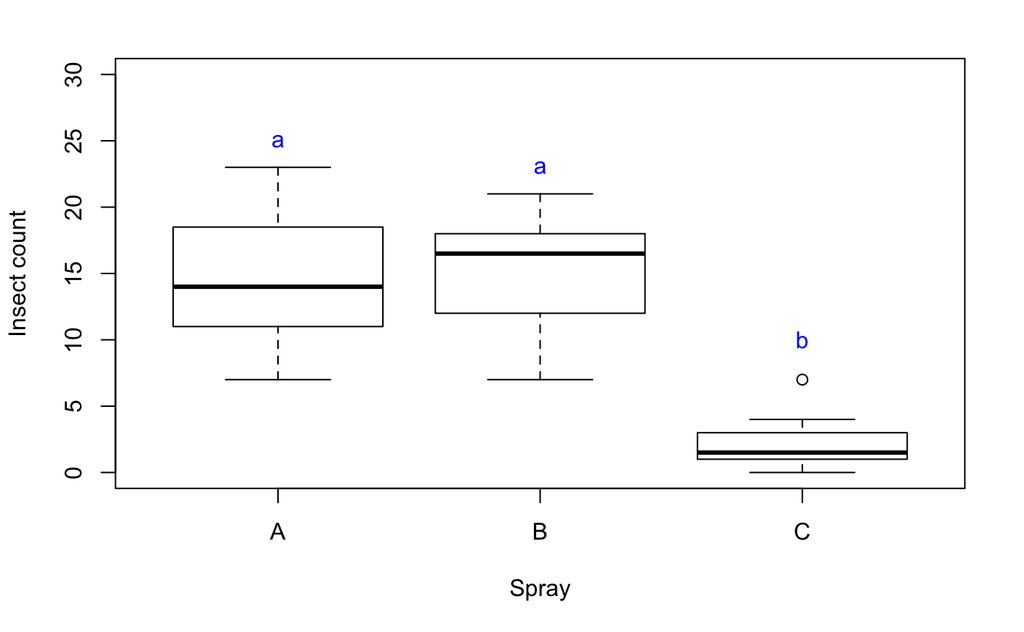

```r
# 3. Plot your results
boxplot(count ~ spray,
        ylim = c(0, 30),
        xlab="Spray",
        ylab = "Insect count",
        data = insect)
letters <- c("a", "a", "b") # results from Tukey
text(x = 1:3, y = c(25, 23, 10), labels = letters, col="blue")
```

** 4. Write a summary statement **

The mean insect counts were not equal across the different insect sprays (one-way ANOVA, F = 44.636, df = 2, P < 0.001). The C spray had significantly less insect counts than the other two sprays (Tukey’s HSD, all p < 0.0001), yet the mean insect counts for A and B sprays were not statistically different (Tukey’s test, P = 0.86).

### Lecture 4. Non-parametric multiple comparisons

```r
cir.kruskal <- kruskal.test(shift ~ treatment, data = cir)
cir.kruskal
```

```
    Kruskal-Wallis rank sum test

data:  shift by treatment
Kruskal-Wallis chi-squared = 9.4231, df = 2, p-value = 0.008991
```

```r
dunn.shift <- with(cir, dunn.test(x = shift,  # x is response
                    g = treatment,  # g is "group"
                    altp = TRUE,  # FALSE if we want alpha = alpha/2
                    list = TRUE,   # provides us with another long list similar to the other multiple comparison tests
                    method = "bonferroni")) # many family-wise error rates (FWER) options for choosing where this test lies on the type 1/type 2 seesaw
```

```
  Kruskal-Wallis rank sum test

data: shift and treatment
Kruskal-Wallis chi-squared = 9.4231, df = 2, p-value = 0.01

                       Comparison of shift by treatment
                                 (Bonferroni)
Col Mean-|
Row Mean |    control       eyes
---------+----------------------
    eyes |   2.778928
         |    0.0164*
    knee |   0.143462  -2.551778
         |     1.0000    0.0322*


List of pairwise comparisons: Z statistic (adjusted p-value)
------------------------------------
control - eyes :  2.778928 (0.0164)*
control - knee :  0.143462 (1.0000)
eyes - knee    : -2.551778 (0.0322)*

alpha = 0.05
Reject Ho if p <= alpha
```

```r
names(dunn.shift) # provides you with the names of the outputs of the function, so that you can use these to extract the outputs you want.
```

```
[1] "chi2"          "Z"             "altP"          "altP.adjusted" "comparisons"
```

```r
dunn.shift$Z # Z test statistic
```

```
[1]  2.7789287  0.1434629 -2.5517789
```

```r
dunn.shift$P.adjusted # P-values
```

[output not shown]

### Exercise 2.

*Data*: Daily air quality measurements on Roosevelt Island, New York in 1973. Test whether the mean ozone (ppb) was different among the three months.

*Instructions:* 1. Run a Kruskal-Wallis test 2. Conduct a Dunn’s test 3. Plot your results 4. Write a summary statement for both the Kruskal-Wallis and Dunn’s tests.

```r
quality <- read.csv("AirQuality.csv")
# 1. Kruskal-Wallis
kruskal.test(Ozone ~ as.factor(Month), data = quality)
```

```
    Kruskal-Wallis rank sum test

data:  Ozone by as.factor(Month)
Kruskal-Wallis chi-squared = 20.705, df = 2, p-value = 3.191e-05
```

```r
# 2. Dunn's test
with(quality, dunn.test(x = Ozone, g = as.factor(Month),  # x is response and g is "group"
                    altp = TRUE, # we want the alpha to be 0.05
                    method = "bonferroni",
                    list = TRUE))
```

```
  Kruskal-Wallis rank sum test

data: Ozone and group
Kruskal-Wallis chi-squared = 20.7053, df = 2, p-value = 0

                         Comparison of Ozone by group
                                 (Bonferroni)
Col Mean-|
Row Mean |          5          7
---------+----------------------
       7 |  -4.425270
         |    0.0000*
       9 |  -1.363129   3.181227
         |     0.5185    0.0044*


List of pairwise comparisons: Z statistic (adjusted p-value)
---------------------------
5 - 7 : -4.425270 (0.0000)*
5 - 9 : -1.363129 (0.5185)
7 - 9 :  3.181227 (0.0044)*

alpha = 0.05
Reject Ho if p <= alpha
```

```r
# 3. Plotting your results
letters <- c("a", "b", "a") # same results as ANOVA
boxplot(Ozone ~ as.factor(Month),
        ylim = c(0, 200),
        xlab="Month",
        ylab = "Ozone",
        xaxt = "n",
        data = quality)
axis(1, at=1:3, labels = c("May", "July", "September"))
```

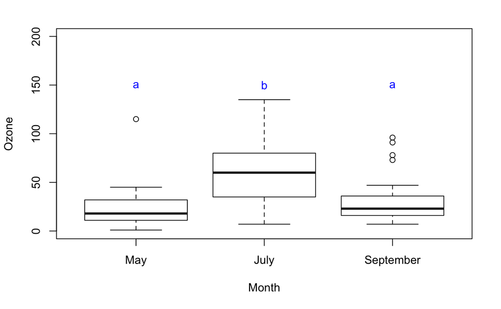

```r
text(x = 1:3, y = 150, labels = letters, col="blue")
```